# Simple Linear Regression

## Mathematical Model

Prediction of one variable from knowledege of another.

Assuming a simple linear relationship between two variables, there exists a relationship of this form:

$$y = \beta_0 + \beta_1 x_1 + \epsilon$$

Where:

$y$: the predicted variable

$\beta_0$: the y-intercept

$\beta_1$: the slope of x_1

$x_1$: the predicting variable

$\epsilon$: the error term

we estimate this relationship with the model:

Mathematical Model:

$$\hat{y} = \hat{\beta_0} + \hat{\beta_1} x_1$$

Where

$\hat{y}$ the estimated value of the dependent, predicted variable

$\hat{\beta_0}$ the estimate value of the y-intercept

$\hat{\beta_1}$ the estimate value of the slope, or x coefficient

$x_1$ the independent, or predictor variable

## Simulating Data

```r
library(tidyverse)
```

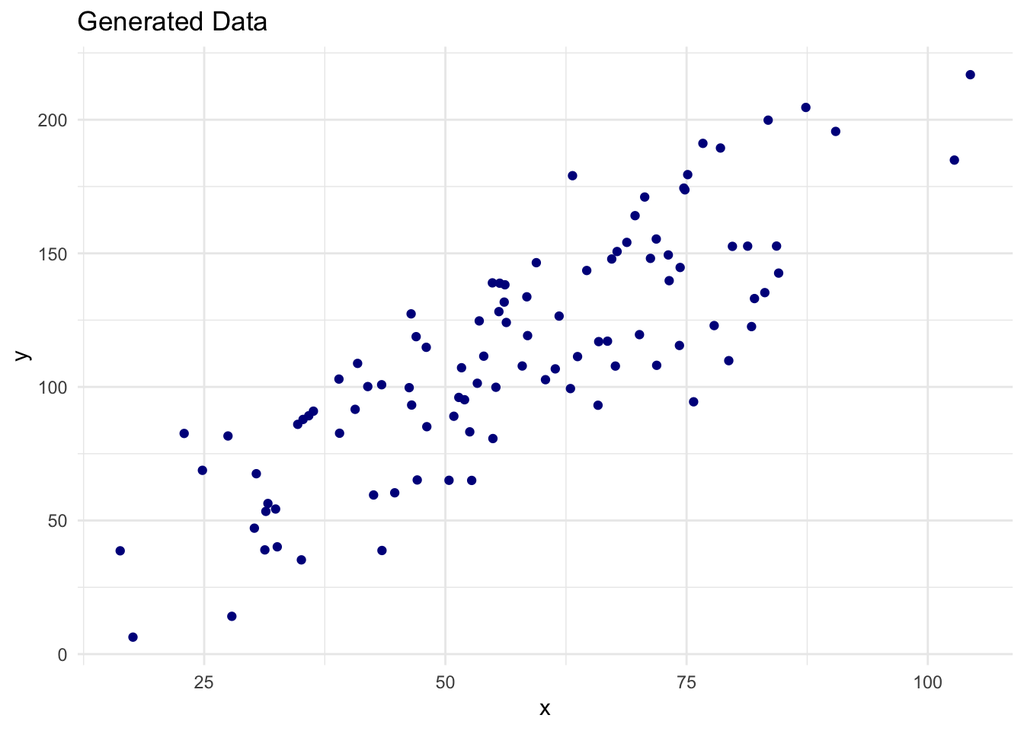

```r
set.seed(10)

# create data
x <- rnorm(100, mean = 60, sd = 20)
eps <- rnorm(100, mean = 0, sd = 25)
y <- 2*x + 1 + eps

# plot data with true model
ggplot() +
  geom_point(aes(y = y, x = x), color = 'darkblue') +
  theme_minimal() +
  ggtitle('Generated Data')
```

## True Relationship

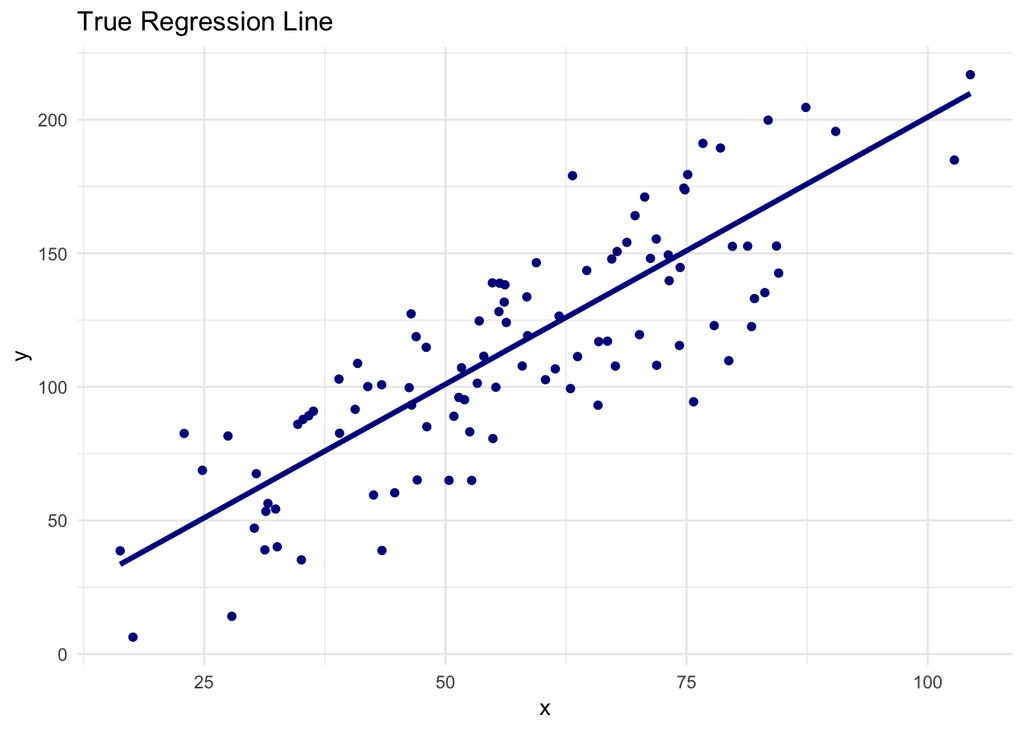

```r
# fitting the true line
ggplot() +
  geom_point(aes(y = y, x = x), color = 'darkblue') +
  geom_line(aes(y = 2*x + 1, x = x),
            size = 1.25, color = 'darkblue') +
  theme_minimal() +
  ggtitle('True Regression Line')
```

## Simple Linear Regression Model

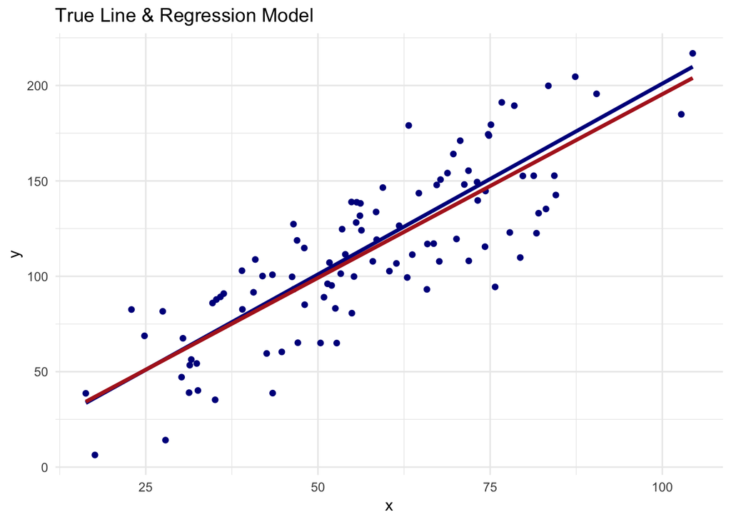

```r
sim_dat <- tibble(x = x, y = y)

fit <- lm(y ~ x, data = sim_dat)

sim_dat %>%
  mutate( model = predict(fit) ) %>%
  ggplot() +
  geom_point(aes(y = y, x = x), color = 'darkblue') +
  geom_line(aes(y = 2*x +1, x = x),
            size = 1.25, color = 'darkblue') +
  geom_line(aes(y = model, x = x),
            size = 1.25, color = 'firebrick') +
  theme_minimal() +
  ggtitle('True Line & Regression Model')
```

## Interpretation

```r
summary(fit)
```

```
##
## Call:
## lm(formula = y ~ x, data = sim_dat)
##
## Residuals:
##     Min      1Q  Median      3Q     Max
## -54.272 -18.962   4.006  18.393  54.521
##
## Coefficients:
##             Estimate Std. Error t value Pr(>|t|)
## (Intercept)   2.9050     7.8233   0.371    0.711
## x             1.9253     0.1298  14.828   <2e-16 ***
## ---
## Signif. codes:  0 '***' 0.001 '**' 0.01 '*' 0.05 '.' 0.1 ' ' 1
##
## Residual standard error: 24.32 on 98 degrees of freedom
## Multiple R-squared:  0.6917, Adjusted R-squared:  0.6886
## F-statistic: 219.9 on 1 and 98 DF,  p-value: < 2.2e-16
```

The real relationship was y = 2x + 1

meaning:

$\beta_0 = 1$

$\beta_1 = 2$

and we set the error term with

```r
eps = rnorm(100, mean = 0, sd = 25)
```

Our model supposes the relationship is y = 1.92 x + 2.9

Meaning:

$\hat{\beta_0}$: 2.9

$\hat{\beta_1}$: 1.92

It did a good job in following the true regression line as seen in the comparison plot.

To learn more about specific interpretation, follow the link you wish:

- Residual Squared Error (RSE)
- R Squared
- Hypothesis Testing Linear Models